# **EDA - Solar Energy Prediction**

GROUP F: ADDISON P., ALBERTO I., DANIEL R., FIDELIS M., VANIA C.

May 22nd 2020

[output not shown]

## Solar dataset

First column is Date from 1994-01-01 to 2007-12-31.

Next 98 contain energy production in solar estations in units of Joules per square meter.

Finally, there are 357 columns with Principal Components that can be used as predictors.

### Location of the 98 Solar Stations

The following map shows the location of the stations.

[interactive chart not shown]

Click the red dots to know the name of a particular station.

### Solar Stations Data

Number of missing values:

```
## [1] 0
```

As the stations are close between them, their data are very similar.

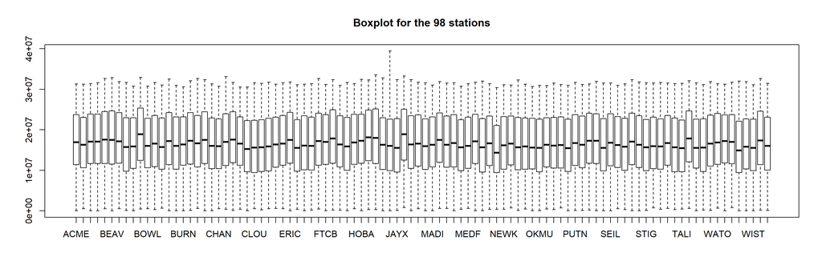

There is a station between HOOK and LAHO that seems to have an unexpected high value, let´s see which it is:

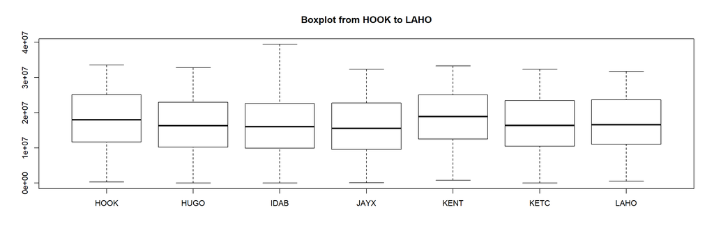

ACME and IDAB are used as examples to analize stations data:

Summary

```
##       ACME               IDAB
##  Min.   :   12000   Min.   :    1200
##  1st Qu.:11404200   1st Qu.: 9927900
##  Median :16946400   Median :15988500
##  Mean   :16877462   Mean   :15849510
##  3rd Qu.:23734800   3rd Qu.:22601100
##  Max.   :31347900   Max.   :39442800
```

Density function to see how often a particular energy value appears:

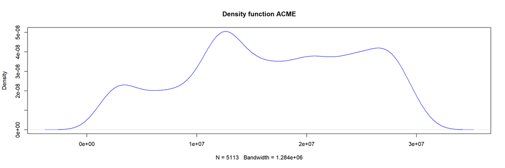

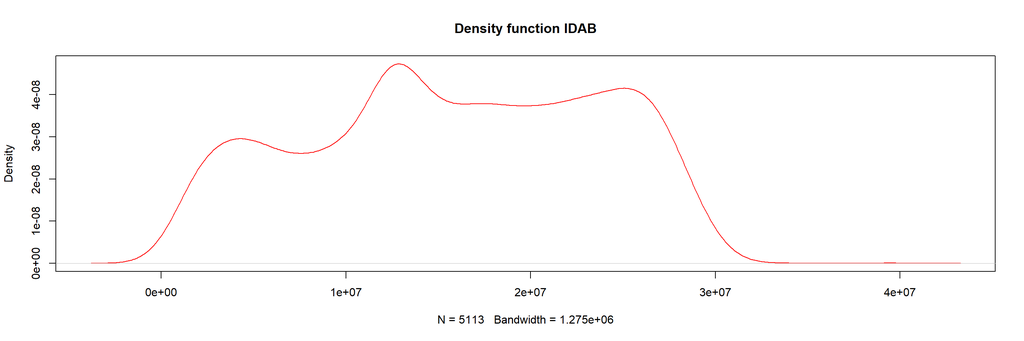

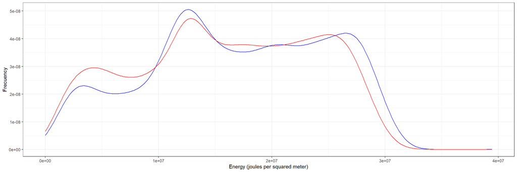

If we plot all the data from a Solar Station we can see the seasonality of energy production:

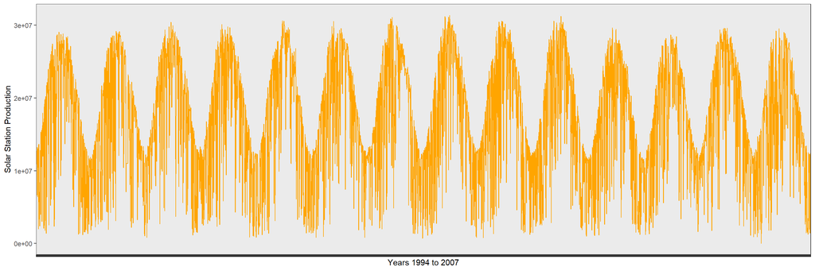

If we zoom in a year we can see the following pattern:

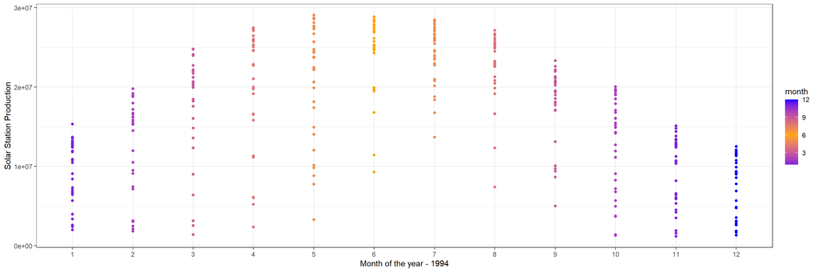

The mean of the energy production in the month of May from 1994 to 2007 has been: 2.15e+07 while in the month of December it has been: 8.58e+06.

### Principal Components Analysis

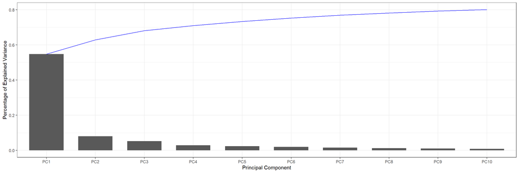

80% of the variance is explained by the first 10 Principal Components

### Additional Variables Analysis

Total missing values in Additional variables dataset are 26733

```
## [1] 7.005355
```

Up to 7% NAs exist for additional_vars (additional_variables dataset)

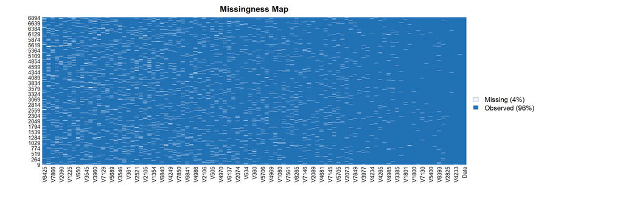

Additional variables have skwed distributions with more that 75% of values = 0 and many sparse outliers:

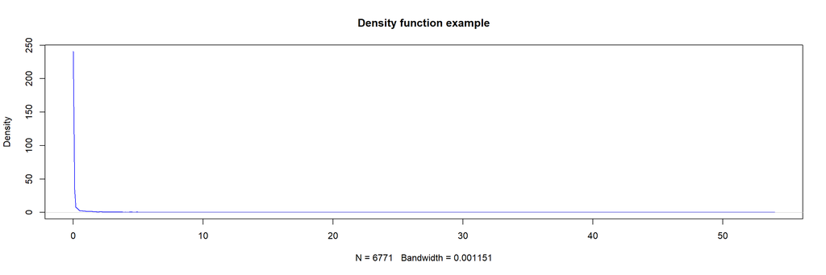

This is why the team decided not to use any of these additional variables for the Machine Learning model.